# survival lecture 6

Steve Simon

May 20, 2018

Lecture 6. Time varying covariates in a Cox model. Time varying covariates allow you to account for non-proportional hazards and can model settings where patients switch from one therapy to another. You will code data for time-varying covariates, fit time-varying models, and interpret the results.

This file does not need any special libraries other than the ones listed below. Many of the data sets in this program use data from Hosmer, Lemeshow, and May. I made one minor change, however, which was to force all the variable names to lower case.

```r
library(broom)
library(dplyr)
```

```r
library(ggplot2)
library(magrittr)
library(survival)
library(tidyr)
```

## The Kaplan-Meier plot and proportional hazards.

```r
fn <- "../../data/whas500.RData"
load(fn)
fn <- "../../data/heroin.txt"
heroin_0 <- read.table(file=fn, skip=1, as.is=TRUE)
v_list <- c(
  "id",
  "clinic",
  "status",
  "time",
  "prison_record",
  "methadone_dose")
names(heroin_0) <- rep(v_list, 2)
head(heroin_0)
```

```
##   id clinic status time prison_record methadone_dose  id clinic status
## 1  1      1      1  428             0             50 132      2      0
## 2  2      1      1  275             1             55 133      2      1
## 3  3      1      1  262             0             55 134      2      1
## 4  4      1      1  183             0             30 135      2      1
## 5  5      1      1  259             1             65 137      2      0
## 6  6      1      1  714             0             55 138      2      0
##   time prison_record methadone_dose
## 1  633             0             70
## 2  661             0             40
## 3  232             1             70
## 4   13             1             60
## 5  563             0             70
## 6  969             0             80
```

```r
heroin <- rbind(heroin_0[ , 1:6], heroin_0[ , 7:12])
heroin$status <- factor(
  heroin$status,
  levels=0:1,
  labels=c("Censored", "Departed"))
heroin$dose_group <- cut(
  heroin$methadone_dose,
  breaks=c(0, 50, 60, 999),
  labels=c("0-50", "51-60", "61+"))
heroin$time_yrs <- heroin$time / 365.25;
table(heroin$methadone_dose, heroin$dose_group)
```

```
##
##       0-50 51-60 61+
##   20     1     0   0
##   30     2     0   0
##   35     2     0   0
##   40    30     0   0
##   45    10     0   0
##   50    27     0   0
##   55     0    21   0
##   60     0    52   0
##   65     0     0  22
##   70     0     0  24
##   75     0     0   6
##   80     0     0  35
##   90     0     0   2
##   100    0     0   3
##   110    0     0   1
```

```r
head(heroin)
```

```
##   id clinic   status time prison_record methadone_dose dose_group
## 1  1      1 Departed  428             0             50       0-50
## 2  2      1 Departed  275             1             55      51-60
## 3  3      1 Departed  262             0             55      51-60
## 4  4      1 Departed  183             0             30       0-50
## 5  5      1 Departed  259             1             65        61+
## 6  6      1 Departed  714             0             55      51-60
##    time_yrs
## 1 1.1718001
## 2 0.7529090
## 3 0.7173169
## 4 0.5010267
## 5 0.7091034
## 6 1.9548255
```

```r
table(heroin$status)
```

```
##
## Censored Departed
##       88      150
```

```r
summary(heroin)
```

```
##        id             clinic           status         time
##  Min.   :  1.00   Min.   :1.000   Censored: 88   Min.   :   2.0
##  1st Qu.: 65.25   1st Qu.:1.000   Departed:150   1st Qu.: 171.2
##  Median :131.50   Median :1.000                  Median : 367.5
##  Mean   :134.13   Mean   :1.315                  Mean   : 402.6
##  3rd Qu.:205.75   3rd Qu.:2.000                  3rd Qu.: 585.5
##  Max.   :266.00   Max.   :2.000                  Max.   :1076.0
##  prison_record    methadone_dose  dose_group    time_yrs
##  Min.   :0.0000   Min.   : 20.0   0-50 :72   Min.   :0.005476
##  1st Qu.:0.0000   1st Qu.: 50.0   51-60:73   1st Qu.:0.468857
##  Median :0.0000   Median : 60.0   61+  :93   Median :1.006160
##  Mean   :0.4664   Mean   : 60.4              Mean   :1.102181
##  3rd Qu.:1.0000   3rd Qu.: 70.0              3rd Qu.:1.603012
##  Max.   :1.0000   Max.   :110.0              Max.   :2.945927
```

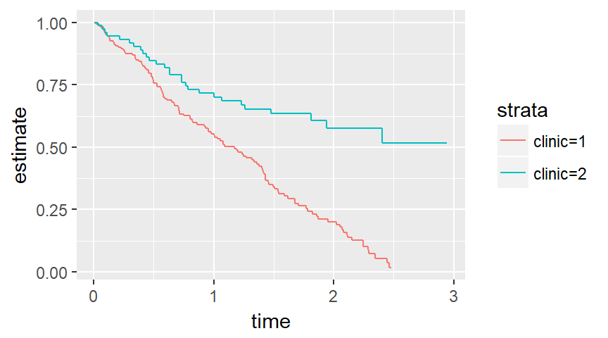

```r
heroin                                      %$%
  Surv(time_yrs, status=="Departed")        -> heroin_surv

heroin                                      %$%
  survfit(heroin_surv~clinic)               %>%
  tidy                                      -> km_clinic

km_clinic                                   %>%
  ggplot(aes(time, estimate, color=strata))  +
    geom_step()
```

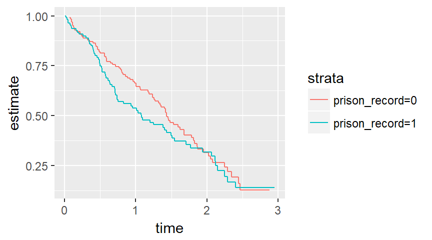

```r
heroin                                      %$%
  survfit(heroin_surv~prison_record)        %>%
  tidy                                      -> km_prison

km_prison                                   %>%
  ggplot(aes(time, estimate, color=strata))  +
    geom_step()
```

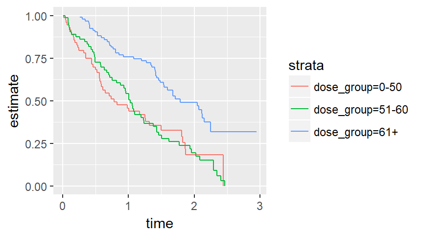

```r
heroin                                      %$%
  survfit(heroin_surv~dose_group)           %>%
  tidy                                      -> km_dose

km_dose                                     %>%
  ggplot(aes(time, estimate, color=strata))  +
    geom_step()
```

## Complementary log-log plot

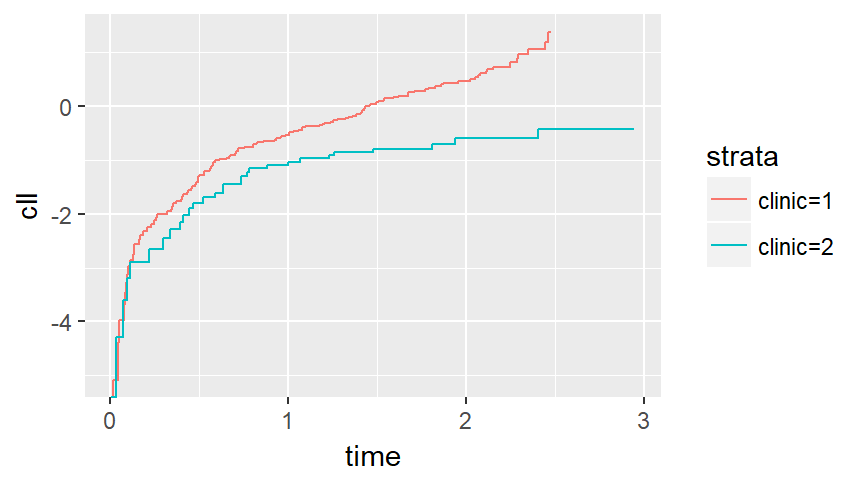

```r
km_clinic                             %>%
  mutate(cll=log(-log(estimate)))     %>%
  ggplot(aes(time, cll, color=strata)) +
    expand_limits(y=0)                 +
    geom_step()
```

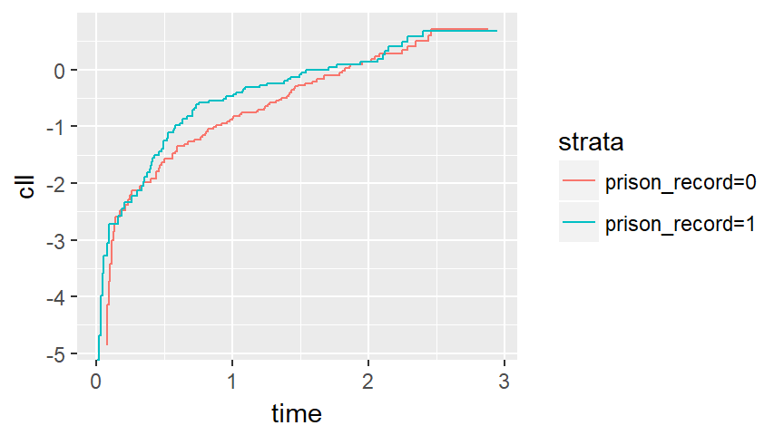

```r
km_prison                             %>%
  mutate(cll=log(-log(estimate)))     %>%
  ggplot(aes(time, cll, color=strata)) +
    expand_limits(y=0)                 +
    geom_step()
```

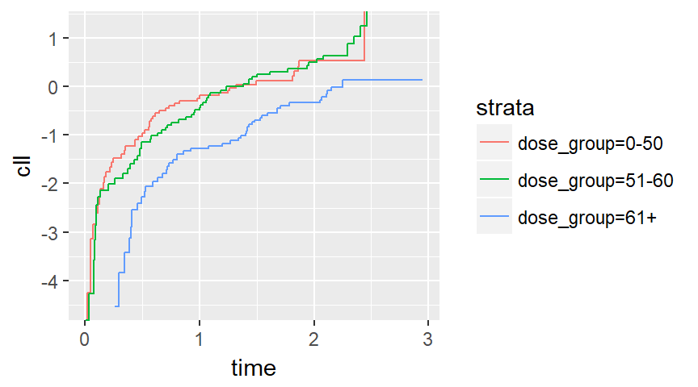

```r
km_dose                               %>%
  mutate(cll=log(-log(estimate)))     %>%
  ggplot(aes(time, cll, color=strata)) +
    expand_limits(y=0)                 +
    geom_step()
```

## Schoenfeld residuals.

```r
par(mar=c(2.6, 4.1, 0.6, 0.6))
cox_mv <- coxph(
  heroin_surv~clinic+prison_record+methadone_dose,
  data=heroin)
cox_schoenfeld <- cox.zph(cox_mv)
print(cox_schoenfeld)
```

```
##                    rho chisq        p
## clinic         -0.2578 11.19 0.000824
## prison_record  -0.0382  0.22 0.639369
## methadone_dose  0.0724  0.70 0.402749
## GLOBAL              NA 12.62 0.005546
```

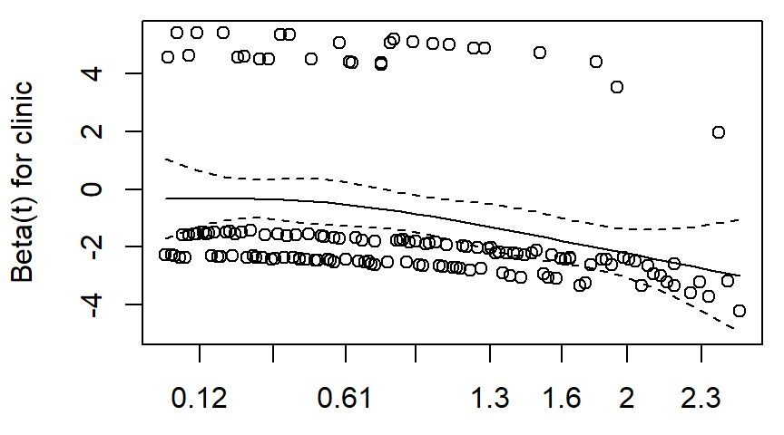

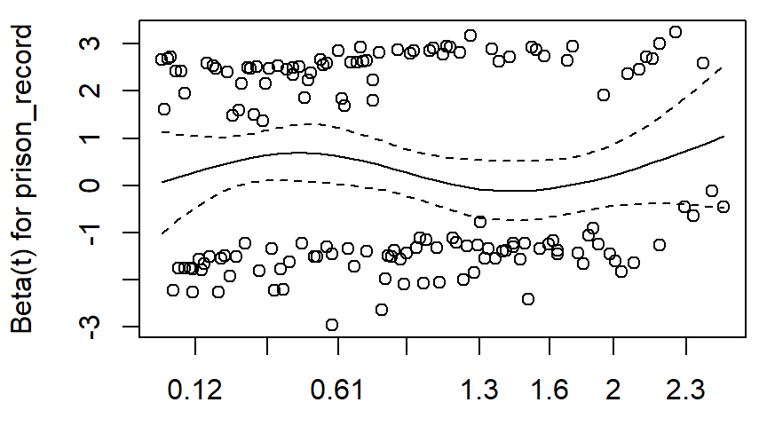

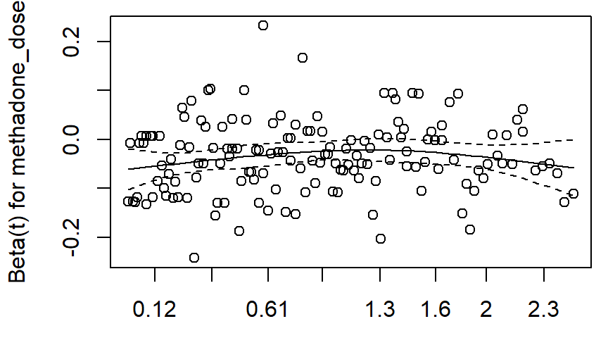

```r
plot(cox_schoenfeld)
```

## Stratified analysis

If one of the variables in your model is a nuisance variable, but it could possibly be the cause of the violation of the proportional hazards assumption, you can fit fix this by fitting a separate baseline hazard for each level of your nuisance variable.

```r
par(mar=c(2.6, 2.6, 0.6, 0.6))
cox_strata <- coxph(
  heroin_surv ~
    prison_record +
    methadone_dose +
  strata(clinic),
  data=heroin)
print(cox_strata)
```

```
## Call:
## coxph(formula = heroin_surv ~ prison_record + methadone_dose +
##     strata(clinic), data = heroin)
##
##                    coef exp(coef) se(coef)     z       p
## prison_record   0.38960   1.47640  0.16893  2.31   0.021
## methadone_dose -0.03511   0.96549  0.00646 -5.43 5.6e-08
##
## Likelihood ratio test=33.9  on 2 df, p=4.32e-08
## n= 238, number of events= 150
```

```r
summary(cox_strata)
```

```
## Call:
## coxph(formula = heroin_surv ~ prison_record + methadone_dose +
##     strata(clinic), data = heroin)
##
##   n= 238, number of events= 150
##
##                     coef exp(coef)  se(coef)      z Pr(>|z|)
## prison_record   0.389605  1.476397  0.168930  2.306   0.0211 *
## methadone_dose -0.035115  0.965495  0.006465 -5.432 5.59e-08 ***
## ---
## Signif. codes:  0 '***' 0.001 '**' 0.01 '*' 0.05 '.' 0.1 ' ' 1
##
##                exp(coef) exp(-coef) lower .95 upper .95
## prison_record     1.4764     0.6773    1.0603    2.0559
## methadone_dose    0.9655     1.0357    0.9533    0.9778
##
## Concordance= 0.651  (se = 0.034 )
## Rsquare= 0.133   (max possible= 0.994 )
## Likelihood ratio test= 33.91  on 2 df,   p=4.322e-08
## Wald test            = 32.66  on 2 df,   p=8.076e-08
## Score (logrank) test = 33.33  on 2 df,   p=5.774e-08
```

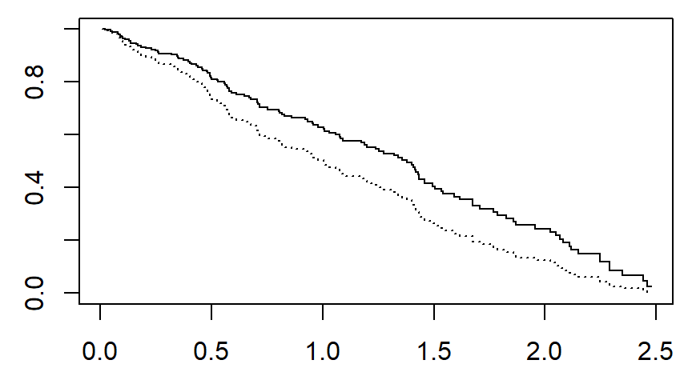

```r
n <- data.frame(
  methadone_dose=mean(heroin$methadone_dose),
  clinic=c(1, 1, 2, 2),
  prison_record=c(0, 1, 0, 1))

cox_predict <- survfit(cox_strata, newdata=n)
plot(
  cox_predict$time[1:147],
  cox_predict$surv[1:147],
  type="s", ylim=c(0,1))
lines(
  cox_predict$time[148:294],
  cox_predict$surv[148:294],
  type="s", lty="dotted")
```

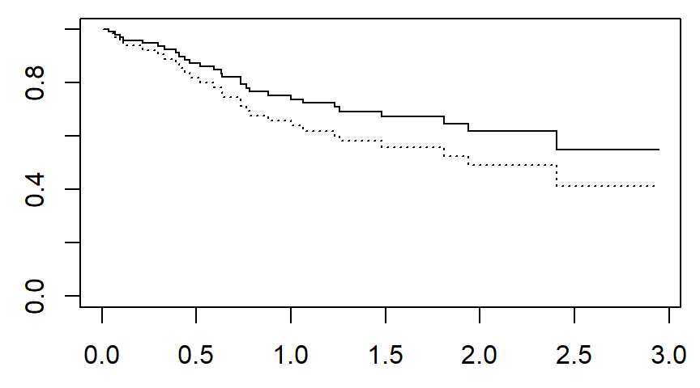

```r
plot(
  cox_predict$time[295:362],
  cox_predict$surv[295:362],
  type="s", ylim=c(0,1))
lines(
  cox_predict$time[363:430],
  cox_predict$surv[363:430],
  type="s", lty="dotted")
```

## Time-varying covariates

```r
par(mar=c(2.6, 2.6, 0.6, 0.6))
tt_clinic <- coxph(
  heroin_surv~
    clinic +
    tt(clinic) +
    prison_record +
    methadone_dose,
  tt=function(x, t, ...) x*t,
  data=heroin)
tt_clinic
```

```
## Call:
## coxph(formula = heroin_surv ~ clinic + tt(clinic) + prison_record +
##     methadone_dose, data = heroin, tt = function(x, t, ...) x *
##     t)
##
##                    coef exp(coef) se(coef)     z       p
## clinic          0.01940   1.01958  0.34717  0.06  0.9554
## tt(clinic)     -1.10331   0.33177  0.34528 -3.20  0.0014
## prison_record   0.38997   1.47693  0.16889  2.31  0.0209
## methadone_dose -0.03519   0.96543  0.00644 -5.46 4.7e-08
##
## Likelihood ratio test=76.1  on 4 df, p=1.11e-15
## n= 238, number of events= 150
```

```r
summary(tt_clinic)
```

```
## Call:
## coxph(formula = heroin_surv ~ clinic + tt(clinic) + prison_record +
##     methadone_dose, data = heroin, tt = function(x, t, ...) x *
##     t)
##
##   n= 238, number of events= 150
##
##                     coef exp(coef)  se(coef)      z Pr(>|z|)
## clinic          0.019395  1.019584  0.347170  0.056   0.9554
## tt(clinic)     -1.103309  0.331771  0.345281 -3.195   0.0014 **
## prison_record   0.389966  1.476931  0.168886  2.309   0.0209 *
## methadone_dose -0.035187  0.965425  0.006443 -5.462 4.72e-08 ***
## ---
## Signif. codes:  0 '***' 0.001 '**' 0.01 '*' 0.05 '.' 0.1 ' ' 1
##
##                exp(coef) exp(-coef) lower .95 upper .95
## clinic            1.0196     0.9808    0.5163    2.0134
## tt(clinic)        0.3318     3.0141    0.1686    0.6527
## prison_record     1.4769     0.6771    1.0607    2.0564
## methadone_dose    0.9654     1.0358    0.9533    0.9777
##
## Concordance= 0.682  (se = 0.279 )
## Rsquare= 0.274   (max possible= 0.997 )
## Likelihood ratio test= 76.13  on 4 df,   p=1.11e-15
## Wald test            = 57.76  on 4 df,   p=8.565e-12
## Score (logrank) test = 67.09  on 4 df,   p=9.348e-14
```

```r
tt_coef <- tidy(tt_clinic)
beta_clinic <- tt_coef[tt_coef$term=="clinic", "estimate"]
beta_interaction <- tt_coef[tt_coef$term=="tt(clinic)", "estimate"]
t <- seq(0, 2.5, by=0.5)
log_hr <- beta_clinic+t*beta_interaction
hr <- exp(log_hr)
round(
  data.frame(
    beta_clinic,
    beta_interaction,
    t,
    log_hr,
    hr),
  3)
```

```
##   beta_clinic beta_interaction   t log_hr    hr
## 1       0.019           -1.103 0.0  0.019 1.020
## 2       0.019           -1.103 0.5 -0.532 0.587
## 3       0.019           -1.103 1.0 -1.084 0.338
## 4       0.019           -1.103 1.5 -1.636 0.195
## 5       0.019           -1.103 2.0 -2.187 0.112
## 6       0.019           -1.103 2.5 -2.739 0.065
```

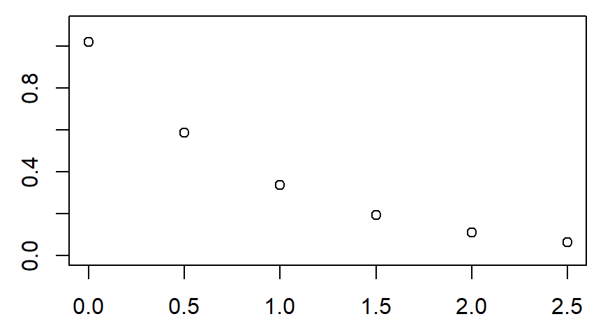

```r
plot(t, hr, ylim=c(0, 1.1))
```

## Stanford Heart Transplant study

The Stanford Heart Transplant study has an interesting application of time-varying covariates.

```r
par(mar=c(2.6, 2.6, 0.6, 0.6), las=1)
ids <- 21:30
vlist <- c(
  "accept.dt",
  "tx.date",
  "fu.date",
  "fustat",
  "transplant"
)
jasa [ids, vlist]
```

```
##     accept.dt    tx.date    fu.date fustat transplant
## 21 1969-02-01 1969-02-08 1971-11-29      1          1
## 22 1969-03-18 1969-03-29 1969-05-07      1          1
## 23 1969-04-11 1969-04-13 1971-04-13      1          1
## 24 1969-04-25 1969-07-16 1969-11-29      1          1
## 25 1969-04-28 1969-05-22 1974-04-01      0          1
## 26 1969-05-01       <NA> 1973-03-01      0          0
## 27 1969-05-04       <NA> 1970-01-21      1          0
## 28 1969-06-07 1969-08-16 1969-08-17      1          1
## 29 1969-07-14       <NA> 1969-08-17      1          0
## 30 1969-08-19 1969-09-03 1971-12-18      1          1
```

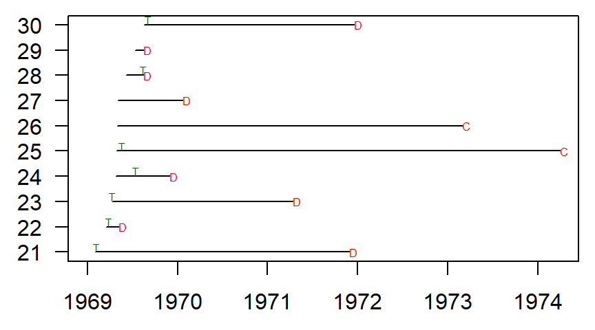

```r
t0 <- as.Date("1969-01-01")
t1 <- jasa$accept.dt[ids] - t0
t2 <- jasa$tx.date[ids] - t0
t3 <- jasa$fu.date[ids] - t0
censor <- ifelse(jasa$fustat[ids]==1, "D", "C")
plot(c(0, max(t3)), c(1,10), type="n", axes=FALSE)
axis(side=1, at=(0:5)*365.25, labels=1969:1974)
axis(side=2, at=1:10, label=ids)
box()
segments(t1, 1:10, t3, 1:10)
text(t2, (1:10)+0.2, "T", col="darkgreen", cex=0.5)
text(t3, 1:10, censor, col="red", adj=0, cex=0.5)
```

```r
data.frame(
  id=ids,
  time1=t2-t1,
  time2=t3-t1,
  event=censor,
  transplant=jasa$transplant[ids])
```

```
##    id   time1     time2 event transplant
## 1  21  7 days 1031 days     D          1
## 2  22 11 days   50 days     D          1
## 3  23  2 days  732 days     D          1
## 4  24 82 days  218 days     D          1
## 5  25 24 days 1799 days     C          1
## 6  26 NA days 1400 days     C          0
## 7  27 NA days  262 days     D          0
## 8  28 70 days   71 days     D          1
## 9  29 NA days   34 days     D          0
## 10 30 15 days  851 days     D          1
```

```r
jasax <- jasa1
row.names(jasax) <- NULL
col.names <- c("id", "start", "stop", "event", "transplant")
jasax[jasax$id %in% ids, col.names]
```

```
##    id start stop event transplant
## 30 21     0    7     0          0
## 31 21     7 1031     1          1
## 32 22     0   11     0          0
## 33 22    11   50     1          1
## 34 23     0    2     0          0
## 35 23     2  732     1          1
## 36 24     0   82     0          0
## 37 24    82  218     1          1
## 38 25     0   24     0          0
## 39 25    24 1799     0          1
## 40 26     0 1400     0          0
## 41 27     0  262     1          0
## 42 28     0   70     0          0
## 43 28    70   71     1          1
## 44 29     0   34     1          0
## 45 30     0   15     0          0
## 46 30    15  851     1          1
```

```r
cox_naive <- coxph(
  Surv(futime, fustat) ~ transplant + age + surgery,
    data=jasa)

print(cox_naive)
```

```
## Call:
## coxph(formula = Surv(futime, fustat) ~ transplant + age + surgery,
##     data = jasa)
##
##               coef exp(coef) se(coef)     z       p
## transplant -1.7171    0.1796   0.2785 -6.16 7.1e-10
## age         0.0589    1.0607   0.0150  3.91 9.1e-05
## surgery    -0.4190    0.6577   0.3712 -1.13    0.26
##
## Likelihood ratio test=45.9  on 3 df, p=6.11e-10
## n= 103, number of events= 75
```

```r
cox_time_varying <- coxph(
  Surv(start, stop, event, type="counting") ~
    transplant+age+surgery,
  data=jasa1)

print(cox_time_varying)
```

```
## Call:
## coxph(formula = Surv(start, stop, event, type = "counting") ~
##     transplant + age + surgery, data = jasa1)
##
##               coef exp(coef) se(coef)     z     p
## transplant  0.0141    1.0142   0.3082  0.05 0.964
## age         0.0306    1.0310   0.0139  2.20 0.028
## surgery    -0.7733    0.4615   0.3597 -2.15 0.032
##
## Likelihood ratio test=10.7  on 3 df, p=0.0134
## n= 170, number of events= 75
```

```r
fn <- "../../data/transplant1.csv"
write.csv(jasa, file=fn, row.names=FALSE, na=".")
fn <- "../../data/transplant2.csv"
write.csv(jasa1, file=fn, row.names=FALSE, na=".")
```

Save everything for possible later re-use.

```r
save.image("../../data/class6.RData")
```